# Practice

Marcus Nunes

17 November, 2019

# 1 Instructions

Save a version of this file and call it `practice_answers.Rmd`. Remove this first section and practice what we learned today, writing a small report analyzing the `iris` dataset.

After your work is done, change the code `output: bookdown::html_document2` on line 5 to `output: bookdown::pdf_document2` in order to have a pdf. It is preferable to work with the HTML version of the report first to save time and create the pdf only after the analysis is complete.

# 2 Introduction

The Iris flower dataset is a well known multivariate dataset introduced in Fisher (1936). It contains 150 observations of three species of plants called *Iris setosa*, *Iris versicolor*, and *Iris virginica*. In this report we will analyze this dataset and show why it is interesting.

# 3 Descriptive Statistics

We will describe the most important features about the Iris flower dataset in this section.

## 3.1 Tables

1. Create a table with the means for `ìris` dataset. Describe your findings.

```r
results <- iris %>%
  select_if(is.numeric) %>%
  summarise_all(list(mean = mean))

kable(results)
```

| Sepal.Length_mean | Sepal.Width_mean | Petal.Length_mean | Petal.Width_mean |
| --- | --- | --- | --- |
| 5.843333 | 3.057333 | 3.758 | 1.199333 |

The variable with the highest mean is Sepal.Length, with 5.84cm.

## 3.2 Plots

2. Make scatter plots showing the relationships between all the numeric variables in this dataset. What you can see?

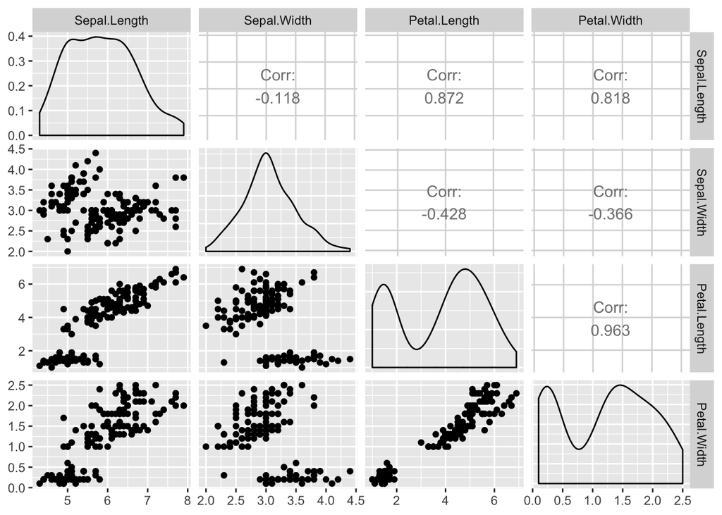

```r
iris %>%
  select_if(is.numeric) %>%
  ggpairs()
```

3. Plot the scatter plot between the two variables with the highest correlation, coloring the points according to the flower species. Is there anything special about this plot?

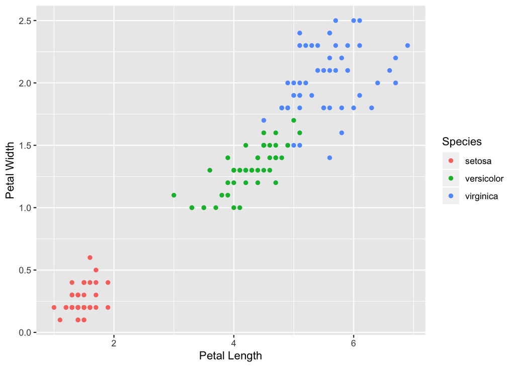

```r
ggplot(iris, aes(x = Petal.Length, y = Petal.Width, colour = Species)) +
  geom_point() +
  labs(x = "Petal Length", y = "Petal Width")
```

There are two main clusters in this plot. One, to the left, with only *Iris setosa*, and other to the right, with both *Iris versicolor* and *virginica*.

# 4 Modeling

4. Fit a linear regression model between the two variables you found on question 3. Use the variable with the highest mean as the predictor variable.

```r
fit <- lm(Petal.Width ~ Petal.Length, data = iris)
kable(summary(fit)$coefficients,
      format = "html",
      caption = "Regression model result when applied to data `iris`.",
      digits = 4) %>%
  kable_styling(position = "center")
```

Table 4.1: Regression model result when applied to data `iris`.

|  | Estimate | Std. Error | t value | Pr(>\|t\|) |
| --- | --- | --- | --- | --- |
| (Intercept) | -0.3631 | 0.0398 | -9.1312 | 0 |
| Petal.Length | 0.4158 | 0.0096 | 43.3872 | 0 |

5. Plot the regression line on the scatter plot.

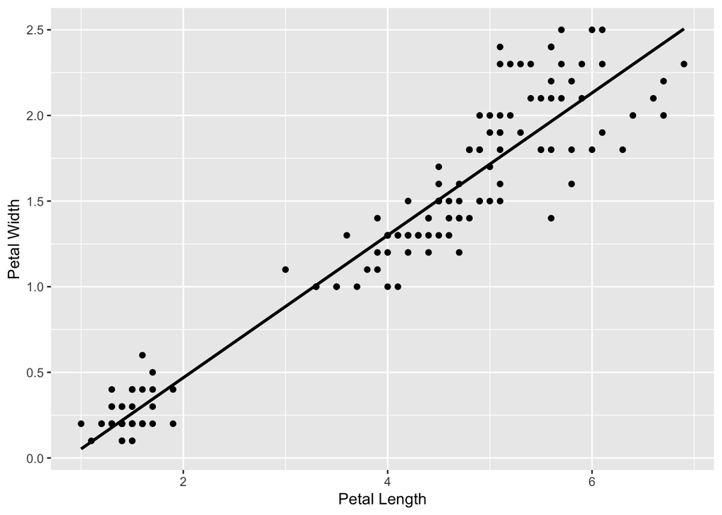

```r
ggplot(iris, aes(x = Petal.Length, y = Petal.Width)) +
  geom_point() +
  geom_smooth(method = "lm", se = FALSE, colour = "black") +
  labs(x = "Petal Length", y = "Petal Width")
```

6. Make a boxplot comparing the observations of the `Sepal.Width` variable between the three plant species. Do you think there is a group whose mean is different from the others?

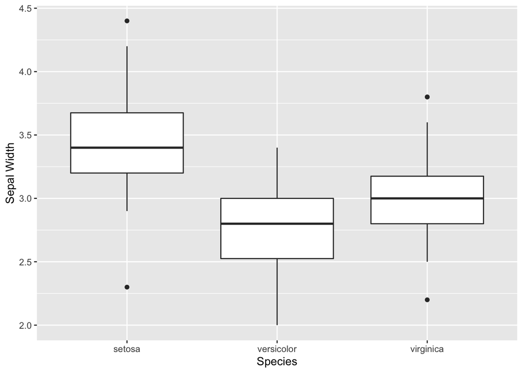

```r
ggplot(iris, aes(x=Species, y=Sepal.Width)) +
  geom_boxplot() +
  labs(x="Species", y="Sepal Width")
```

7. Test the hypothesis

$$\begin{align*}
H_0 &: \mu_1 = \mu_2 = \mu_3 \\
H_0 &: \mbox{at least one pair $\mu_i \neq \mu_j$, if $i \neq j$}
\end{align*}$$

where $\mu_i$ is the mean for the variable `Sepal.Width` for the groups

- $i = 1 \mbox{ (setosa})$
- $i = 2 \mbox{ (versicolor})$
- $i = 3 \mbox{ (virginica})$

What is your conclusion?

```r
fit.anova <- aov(Sepal.Width ~ Species, data = iris)
results.anova <- summary(fit.anova)
options(knitr.kable.NA = "")
kable(results.anova[[1]])
```

|  | Df | Sum Sq | Mean Sq | F value | Pr(>F) |
| --- | --- | --- | --- | --- | --- |
| Species | 2 | 11.34493 | 5.6724667 | 49.16004 | 0 |
| Residuals | 147 | 16.96200 | 0.1153878 |  |  |

Since p-value = 0, we reject $H_0$ at level $\alpha = 0,05$. Therefore, there is at least one pair $\mu_i \neq \mu_j$, if $i \neq j$.

# 5 Conclusion

As we could see, this dataset is great to practice statistical concepts.

# References

Fisher, R. A. 1936. “The Use of Multiple Measurements in Taxonomic Problems.” *Annals of Eugenics* 7 (7): 179–88.